# DC Taxicab Notebook

Authors: William Cassidy and Walter Zhang

Date: May 8, 2018

RCC Deep Learning Hackathon

[Github Repository](https://github.com/wmcass/DCTaxiCab/)

In this notebook, we examine ride "coincidence" for a subset of the February 2017 data. The data can be found [here](http://opendata.dc.gov/datasets/taxicab-trips-sampling-in-february-2017), and we pre-process the data by dropping all trips that do not report locations or transactions.

We are interested in looking at the ride "coincidences" to examine if a spike in coincident rides predate political leaks. Specifically, we want to consider all rides originating for two zones (i.e. the White House and the Washington Post headquarters) and then denote the rides as "coincidences" if they have the same drop off block and arrive within an hour of each other.

We first examine all of the drop off and pick up locations in our sample

```python
# import tensorflow as tf
import pandas as pd
import matplotlib.pyplot as plt
import numpy as np
import geopandas as gpd
import pickle
import datetime as dt

plt.style.use('fivethirtyeight')

plt.rcParams['figure.figsize'] = [10,10]

root = r'/project/rcc/deep_learning_hack/dc-taxi/DCTaxiCab/'

data_location = "/project/rcc/deep_learning_hack/dc-taxi/DCTaxiCab/data/sample/"
data_file = "Taxicab_Trips_Sampling_in_February_2017-Cleaned.csv"
```

```python
sample_DF = pd.read_csv(data_location + data_file)
```

```python
sample_DF.shape
```

```
(30077, 31)
```

In this sample, we have a data set of thirty thousand trips.

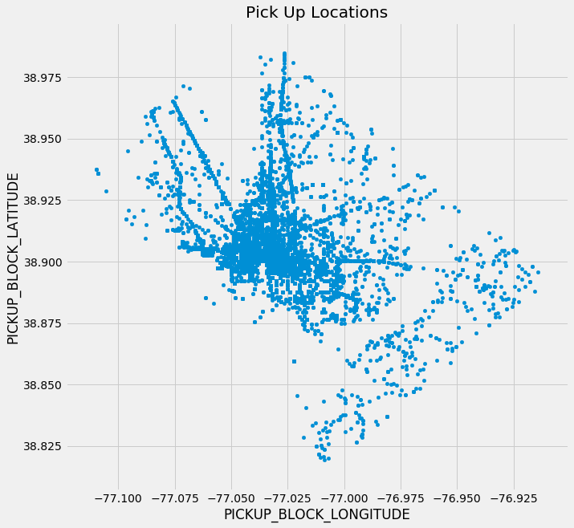

```python
sample_DF.plot.scatter('PICKUP_BLOCK_LONGITUDE', 'PICKUP_BLOCK_LATITUDE', title = "Pick Up Locations")
```

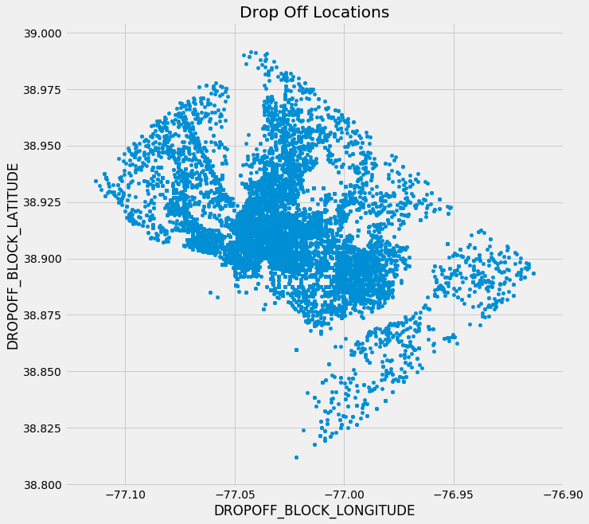

```python
sample_DF.plot.scatter('DROPOFF_BLOCK_LONGITUDE', 'DROPOFF_BLOCK_LATITUDE', title = "Drop Off Locations")
```

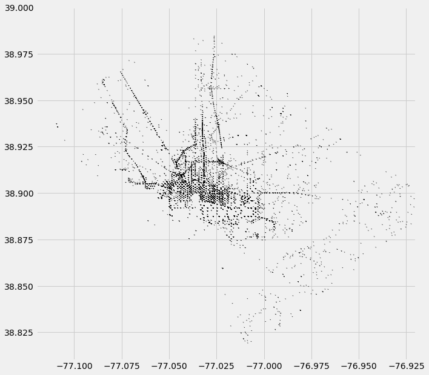

```python
# Quiver Plot
plt.figure()
plt.xlim(-77.12, -76.92)
plt.ylim(38.810, 39.000)

plt.quiver(sample_DF.PICKUP_BLOCK_LONGITUDE,
             sample_DF.PICKUP_BLOCK_LATITUDE,
             sample_DF.DROPOFF_BLOCK_LONGITUDE,
             sample_DF.DROPOFF_BLOCK_LATITUDE,
             units = "x", pivot='tip')

plt.show()
```

The quiver plot shows the general "flow" of the rides from pick up to drop off. We see that we can recover some of the main roads in the DC area with this plot.

# Coincidence Analysis

We now turn towards to coincidence analysis and compute the number of coincidence rides from two areas of interest. We define four possible areas of interest and then specifically examine rides from the White House and the Washington Post. For our areas of interest, we draw a rectangle around the landmark and deem rides that have a pick up location in the rectangle to be a ride originating from that area.

```python
# Squares of Interest
## Top Left then bottom right
## [[Latitude, Longtitude], [Latitude, Longtitude]]
WH_square = [[38.901187, -77.041623],[38.895062, -77.031594]]
CP_square = [[38.896103, -77.012120], [38.884442, -77.003512]]
FBI_square = [[38.896405, -77.026258], [38.893540, -77.023260]]
WP_square = [[38.903954, -77.032217], [38.902334, -77.029411]]
```

```python
'''
in_square
Returns a boolean of True/False if the coordinate
is in the square or not.

Sample Usage: in_square(WH_square[0][0], WH_square[0][1], WH_square)
'''
def in_square(coordinate_lat, coordinate_lon, square_coordinates):
    if square_coordinates[1][0] <= coordinate_lat <= square_coordinates[0][0]:
        if square_coordinates[0][1] <= coordinate_lon <= square_coordinates[1][1]:
            return True
    return False
```

```python
DF = sample_DF
square_1 = WH_square
square_2 = WP_square
time_range =  pd.Timedelta('1 hour')
```

```python
# Reduce DF to only rides originating out of thes square_1 and square_2
in_square_1 = DF[['PICKUP_BLOCK_LATITUDE','PICKUP_BLOCK_LONGITUDE']].apply(lambda row: in_square(row[0], row[1], square_1), 1)
in_square_2 = DF[['PICKUP_BLOCK_LATITUDE','PICKUP_BLOCK_LONGITUDE']].apply(lambda row: in_square(row[0], row[1], square_2), 1)
```

```python
np.count_nonzero(in_square_1)/len(in_square_1)
```

```
0.053562522857997806
```

```python
np.count_nonzero(in_square_2)/len(in_square_2)
```

```
0.0046214715563387306
```

In our data, we see that around 5% of all cab rides originate from the area around White House and 0.5% of all cab rides originate from the Washington Post.

```python
DF = DF[in_square_1 | in_square_2]
```

```python
dropoff_DF = DF[['DROPOFF_BLOCK_LATITUDE','DROPOFF_BLOCK_LONGITUDE']].drop_duplicates()
subset_DF = DF[['DROPOFF_BLOCK_LATITUDE','DROPOFF_BLOCK_LONGITUDE', 'PICKUP_BLOCK_LATITUDE','PICKUP_BLOCK_LONGITUDE',"DROPOFFDATETIME_TR"]]
subset_DF['DROPOFFDATETIME_TR'] = subset_DF['DROPOFFDATETIME_TR'].astype('datetime64[ns]')
```

```python
result_list = []

for dropoff_index, dropoff_row in dropoff_DF.iterrows():
    dropoff_lat = dropoff_row[0]
    dropoff_lon = dropoff_row[1]
    # Check if pickups are an hour apart
    pickup_DF = subset_DF.loc[(subset_DF['DROPOFF_BLOCK_LATITUDE'] == dropoff_lat) & (subset_DF['DROPOFF_BLOCK_LONGITUDE'] == dropoff_lon)]
    if pickup_DF.shape[0] == 1:
        continue
    for pickup_index_1 in range(pickup_DF.shape[0] - 1):
        for pickup_index_2 in range(pickup_index_1 + 1, pickup_DF.shape[0]):
            # Check if they are within an hour of each other
            date_1 = pickup_DF.iloc[pickup_index_1]['DROPOFFDATETIME_TR']
            date_2 = pickup_DF.iloc[pickup_index_2]['DROPOFFDATETIME_TR']
            if abs(date_2 - date_1) <= time_range:
                result_list.append([pickup_DF.index[pickup_index_1], pickup_DF.index[pickup_index_2]])
```

```python
len(result_list)
```

```
297
```

Out of this data sample, we have thee hundred coincident rides that arrive within a hour of each other.

## Plot the Coincidence by Day

We are interest in seeing the number of coincident rides by day. We aim to examines the relation of the time series of coincident rides per day to a time series of tweets per day for a specific topic.

```python
plot_DF = sample_DF
plot_DF['DROPOFFDATETIME_TR'] = plot_DF['DROPOFFDATETIME_TR'].astype('datetime64[ns]')
```

```python
date_list = []

for results_pair in result_list:
    first_index = results_pair[0]
    date_list.append(plot_DF.iloc[first_index]['DROPOFFDATETIME_TR'])
```

```python
date_DF = pd.DataFrame({"date": date_list})
#date_DF
graph_count_DF = date_DF.groupby(["date"]).size()
```

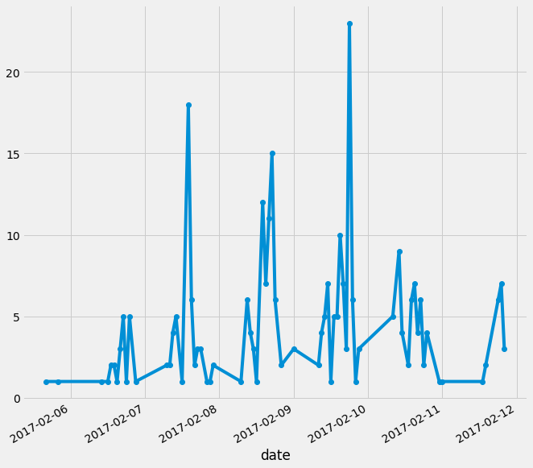

```python
graph_count_DF.plot(marker='o')
```

```python
print(graph_count_DF.idxmax())
print(graph_count_DF.max())
```

```
2017-02-09 18:00:00
23
```

We find a general cyclical pattern of coincident rides. However, there is an evident spike on February 9th at 6 PM.

## Coincidence Rides Map Visualization

Just to get a sense of where the drop off locations are for the coincidence rides, we plot the drop off location on a map of DC streets. We get the shape file of the DC roads from [here](http://opendata.dc.gov/datasets/street-centerlines).

```python
shape_file_location = "/project/rcc/deep_learning_hack/dc-taxi/DCTaxiCab/data/shapefiles/Street_Centerlines_shapefiles/Street_Centerlines.dbf"
dc_shape = gpd.read_file(shape_file_location)
```

```python
'''
get_rec_vertex

Determine the verticies of the rectangle
given the top left and bottom right coordinates

'''
def get_rec_vertex(coordinate):
    a = coordinate[0][0]
    b = coordinate[0][1]
    c = coordinate[1][0]
    d = coordinate[1][1]
    horz_diff = c - a
    vert_diff = b - d
    x_list = [a, a + horz_diff,
              a + horz_diff, a]
    y_list = [b, b, b - vert_diff,
             b - vert_diff]
    return x_list, y_list
```

```python
# Get a dataframe of the latitudes and longitudes of the coincidence data
drop_off_list = []

for results_pair in result_list:
    first_index = results_pair[0]
    drop_off_list.append([plot_DF.iloc[first_index]['DROPOFF_BLOCK_LATITUDE'],
                          plot_DF.iloc[first_index]['DROPOFF_BLOCK_LONGITUDE']])
```

```python
drop_off_DF = pd.DataFrame(drop_off_list)
drop_off_DF.columns = ['LATITUDE', 'LONGITUDE']
drop_off_DF = drop_off_DF.drop_duplicates()
```

```python
WH_vertex = get_rec_vertex(WH_square)
WP_vertex = get_rec_vertex(WP_square)
```

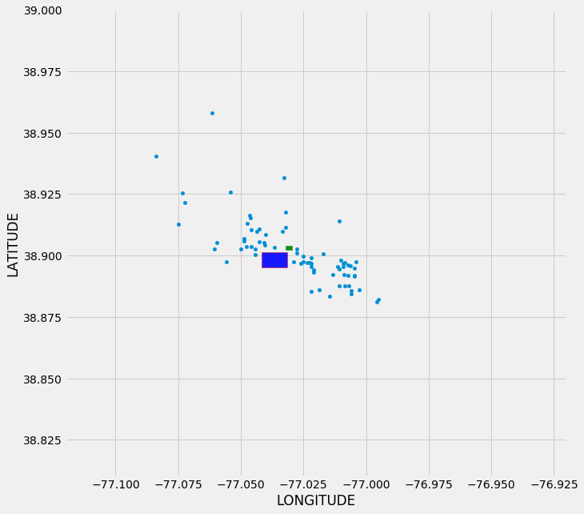

```python
ax = drop_off_DF.plot.scatter('LONGITUDE', 'LATITUDE')
ax.fill(WH_vertex[1], WH_vertex[0], 'b', alpha=0.9, edgecolor='r')
ax.fill(WP_vertex[1], WP_vertex[0], 'g', alpha=0.9, edgecolor='g')
ax.set_xlim(-77.12, -76.92)
ax.set_ylim(38.810, 39.000)
plt.show()
```

We plot the a blue box for our White House origination area and a green box for the Washington Post origination area. The dots are the drop off points of coincident rides.

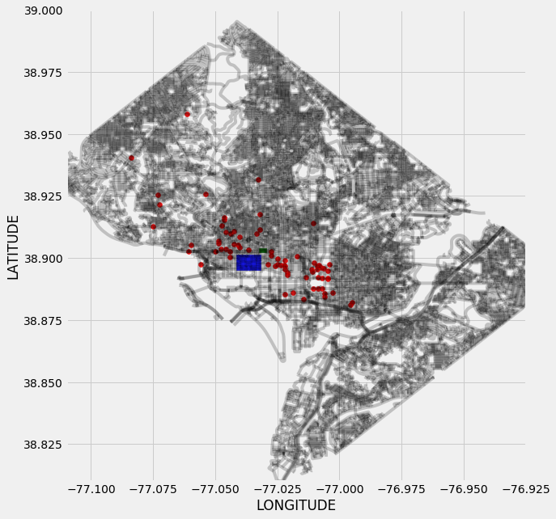

```python
ax = dc_shape.plot(alpha = 0.2, color = 'k')
ax.scatter(drop_off_DF['LONGITUDE'], drop_off_DF['LATITUDE'],
           color = 'r', alpha = 0.9)
ax.fill(WH_vertex[1], WH_vertex[0], color = 'b',
        alpha=0.9, edgecolor='y')
ax.fill(WP_vertex[1], WP_vertex[0], color = 'g',
        alpha=0.9, edgecolor='y')
ax.set_xlim(-77.11, -76.925)
ax.set_ylim(38.810, 39.000)
ax.set_xlabel("LONGITUDE")
ax.set_ylabel("LATITUDE")
plt.show()
```

We also consider the only coincident rides on February 9th and February 10th.

```python
# Get a dataframe of the latitudes and longitudes of the coincidence data
drop_off_date_list = []

for results_pair in result_list:
    first_index = results_pair[0]
    drop_off_date_list.append([plot_DF.iloc[first_index]['DROPOFF_BLOCK_LATITUDE'],
                          plot_DF.iloc[first_index]['DROPOFF_BLOCK_LONGITUDE'],
                          plot_DF.iloc[first_index]['DROPOFFDATETIME_TR']])

drop_off_date_DF = pd.DataFrame(drop_off_date_list)
drop_off_date_DF.columns = ['LATITUDE', 'LONGITUDE', 'DROPOFFDATETIME']
drop_off_date_DF = drop_off_date_DF.drop_duplicates()
```

```python
drop_off_date = drop_off_date_DF['DROPOFFDATETIME']
drop_off_date = drop_off_date.apply(lambda x: x.replace(hour=0, minute=0, second=0, microsecond=0), 1)
```

```python
drop_off_date_specific_DF = drop_off_date_DF[(drop_off_date == pd.to_datetime('2017-02-09')) | (drop_off_date == pd.to_datetime('2017-02-10'))]
```

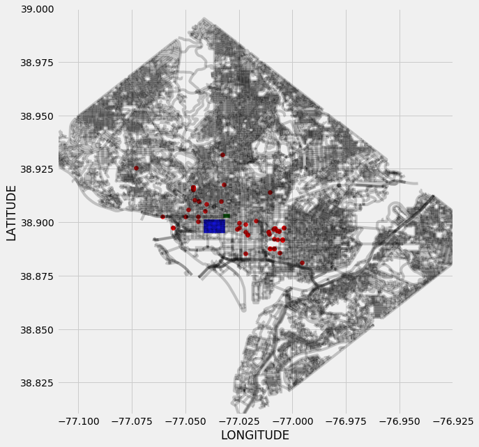

```python
# Only For Feb 9th and 10th
ax = dc_shape.plot(alpha = 0.2, color = 'k')
ax.scatter(drop_off_date_specific_DF['LONGITUDE'], drop_off_date_specific_DF['LATITUDE'],
           color = 'r', alpha = 0.9)
ax.fill(WH_vertex[1], WH_vertex[0], color = 'b',
        alpha=0.9, edgecolor='y')
ax.fill(WP_vertex[1], WP_vertex[0], color = 'g',
        alpha=0.9, edgecolor='y')
ax.set_xlim(-77.11, -76.925)
ax.set_ylim(38.810, 39.000)
ax.set_xlabel("LONGITUDE")
ax.set_ylabel("LATITUDE")
plt.show()
```

```python
tweets = pd.read_csv(root + 'data/twitter/intermediate/tweets.csv')

tweets.created_at = pd.to_datetime(tweets.created_at)
tweets['date'] = tweets.created_at.apply(lambda x: x.replace(minute=0, second=0, microsecond=0))
```

```python
def visualize(df, idx, title, filename):
    '''plot given a dataframe'''

    plt.style.use('fivethirtyeight')

    plt.rcParams['figure.figsize'] = [10, 10]

    val_counts = pd.DataFrame(df.loc[idx, 'date'].value_counts()).reset_index()
    val_counts.columns = ['date', 'count']

    val_counts = val_counts[val_counts.date.dt.month == 2]

    val_counts.sort_values(by='date', inplace=True)

    val_counts.plot(x='date', y='count', title=title)

    plt.axvline(x=dt.datetime(2017, 2, 9, 18, 0, 0), color='black')

    ax = plt.gca()

    ax.spines['right'].set_visible(False)
    ax.spines['top'].set_visible(False)

    ax.yaxis.set_ticks_position('left')
    ax.xaxis.set_ticks_position('bottom')

    plt.savefig(root + '/output/figures/' + filename)

    return None
```

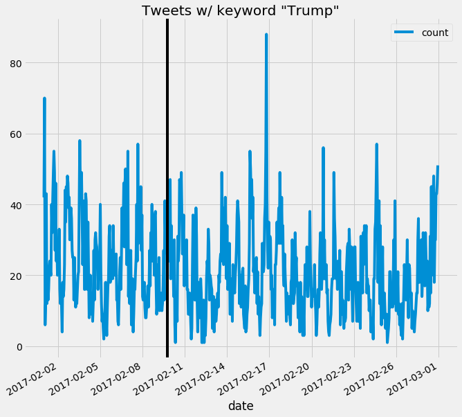

```python
visualize(tweets, tweets.trump, 'Tweets w/ keyword "Trump"', 'trump_tweets.jpg')
```

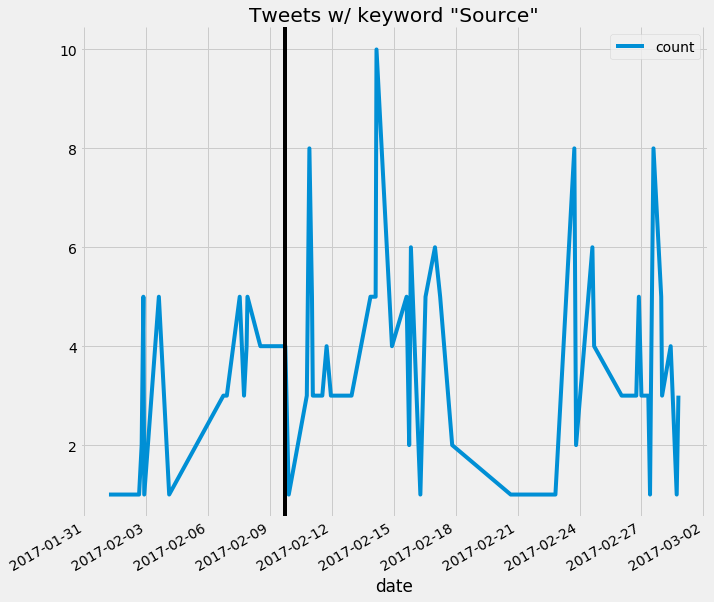

```python
visualize(tweets, (tweets.source), 'Tweets w/ keyword "Source"', 'source_tweets.jpg')
```

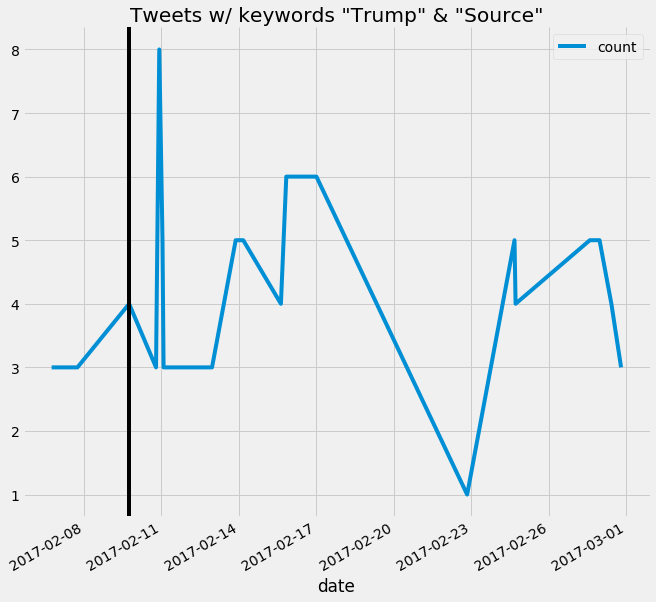

```python
visualize(tweets, (tweets.source & tweets.trump),
          'Tweets w/ keywords "Trump" & "Source"',
          'trump_and_source_tweets.jpg')
```

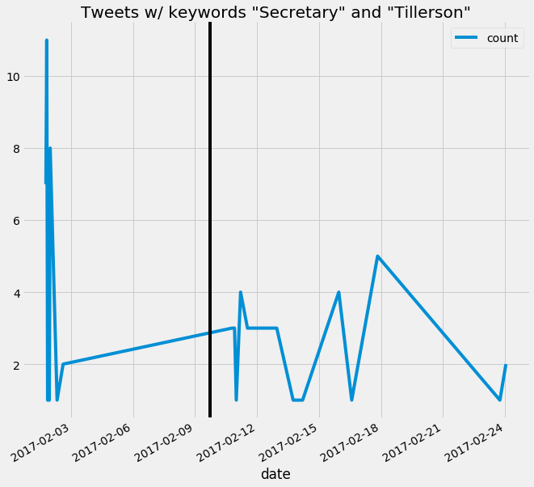

```python
visualize(tweets, tweets.secretary & tweets.tillerson,
          'Tweets w/ keywords "Secretary" and "Tillerson"',
          'secretary_and_tillerson_tweets.jpg')
```

```python
tweets.loc[tweets.source & tweets.trump & (tweets.date.dt.day == 10), ['date', 'text']]
```

|  | date | text |
| --- | --- | --- |
| 3856 | 2017-02-10 22:00:00 | trump won't immediately appeal travel ban bloc... |
| 5533 | 2017-02-10 22:00:00 | trump dumped tillerson's deputy secretary of s... |
| 6595 | 2017-02-10 22:00:00 | trump won't immediately appeal travel ban bloc... |
| 11993 | 2017-02-10 19:00:00 | trump dumped tillerson's deputy secretary of s... |
| 13539 | 2017-02-10 22:00:00 | trump won't immediately appeal travel ban bloc... |
| 14565 | 2017-02-10 22:00:00 | trump dumped tillerson's deputy secretary of s... |
| 15820 | 2017-02-10 22:00:00 | trump won't immediately appeal travel ban bloc... |
| 21717 | 2017-02-10 19:00:00 | trump dumped tillerson's deputy secretary of s... |
| 24128 | 2017-02-10 22:00:00 | trump won't immediately appeal travel ban bloc... |
| 28937 | 2017-02-10 22:00:00 | trump dumped tillerson's deputy secretary of s... |
| 40700 | 2017-02-10 19:00:00 | trump dumped tillerson's deputy secretary of s... |

```python
tweets.loc[5533, 'text']
```

```
"trump dumped tillerson's deputy secretary of state pick over his criticisms during the campaign, sources say\x85 https://t.co/cx7a98p31x"
```